# Executive Summary

## **Background:**

This anonymized public dataset is from *Waze*, a subsidiary company of Google that provides satellite navigation software. It has been made available for training machine learning and reporting techniques in an industry typical challenge of churn classification. However, this dataset contains irregularities, missing values, and outliers. The *purpose* is to find factors that drive user churn to provide recommendation strategies for Waze retention team. This includes fine-tuning a machine learning model using these factors to predict whether or not a Waze user will churn so that the factors most responsible for churn can form the basis of a retention strategy.

## **Findings:**

[figure not shown]

Approximately 17.7% of users churned in the dataset, which might be too low to produce reliable analysis and model training. Correlation analysis showed that the number of days active,days driving and user tenure had been correlated towards a lower chance of churn (average -0.24). However, as active and driving had an extremely high (0.95) correlation with each other, only one was likely to be informative. In addition, some fields for percentages and ratios exceeded 100%, revealing errors in the dataset. This included `percent_sessions_in_last_month`, `percent_sessions_to_favorite`,`km_per_driving_day`,`sessions_per_day` ,`km_per_hour` and likely would be inreliable predictors of churn.

Higher number of days active (and driving days) was an indicator of engagement and therefore retention. The high sessions per day might indicate users that are experiencing technical issues and having to restart frequently as a result. High total navigations to a favorite spot as an indicator of churn makes sense in the context of experiencing issues with the application, as well as the app adding limited value to well-known routes. Beyond these indicators, the impact is less clear.

## **Modeling:**

An XGBoost model provided the best analysis; however, the model's performance was much weaker than expected. Default decision-making threshold yielded a model with recall score of 0.215 and accuracy of 80.4% while an ROC-adjusted threshold (0.032) achieved higher recall (0.729) at the expense of accuracy (0.547).

Shap values were used to judge the impact of each factor within the data and make the recommendations below. The following recommendations should be taken with these scores in mind.

[figure not shown]

## **Model Results:**

Active days within the last month were the strongest indicator ($-3.12<shap<2.73$), along with days after onboarding ($-2.61<shap<1.78$) and use of the favorites feature of navigation ($-1.16<shap<2.22$).

[figure not shown]

## **Recommendations:**

[figure not shown]

## Initial Pre-data Work

1. What are you being asked to do?
- Establishing whether a model and predict churn with the existing dataset
- Identifying factors that drive churn based on model weights, feature importance
2. What are the consequences of your model making errors?
- False positives may leave to undue resource use
- False negatives lead to churn
3. Do the benefits of such a model outweigh the potential problems?
- If the predictive ability is too low, the feature importances will not help inform the design of a retention campaign or allow for accurate user targeting.

# Imports and data loading

```python
# data manipulation
import pandas as pd
import numpy as np
import os
# data visualization
import matplotlib.pyplot as plt
import seaborn as sns
from IPython.display import display
# setups
# set favorite theme
sns.set_theme(style="whitegrid")
# see all of the columns
pd.set_option("display.max_columns",None)
# data modeling
from sklearn.metrics import accuracy_score,f1_score,recall_score,precision_score,confusion_matrix,roc_curve
from sklearn.model_selection import train_test_split,RandomizedSearchCV,GridSearchCV
from sklearn.ensemble import RandomForestClassifier
from sklearn.tree import DecisionTreeClassifier
from xgboost import XGBClassifier
# plot importance
import shap

# save our models
import pickle
import joblib
```

```python
# Import dataset
df = pd.read_csv('waze_dataset.csv')
df.head()
```

|  | ID | label | sessions | drives | total_sessions | n_days_after_onboarding | total_navigations_fav1 | total_navigations_fav2 | driven_km_drives | duration_minutes_drives | activity_days | driving_days | device |
| --- | --- | --- | --- | --- | --- | --- | --- | --- | --- | --- | --- | --- | --- |
| 0 | 0 | retained | 283 | 226 | 296.748273 | 2276 | 208 | 0 | 2628.845068 | 1985.775061 | 28 | 19 | Android |
| 1 | 1 | retained | 133 | 107 | 326.896596 | 1225 | 19 | 64 | 13715.920550 | 3160.472914 | 13 | 11 | iPhone |
| 2 | 2 | retained | 114 | 95 | 135.522926 | 2651 | 0 | 0 | 3059.148818 | 1610.735904 | 14 | 8 | Android |
| 3 | 3 | retained | 49 | 40 | 67.589221 | 15 | 322 | 7 | 913.591123 | 587.196542 | 7 | 3 | iPhone |
| 4 | 4 | retained | 84 | 68 | 168.247020 | 1562 | 166 | 5 | 3950.202008 | 1219.555924 | 27 | 18 | Android |

```python
# load col names into memory
df.info()
```

```
<class 'pandas.core.frame.DataFrame'>
RangeIndex: 14999 entries, 0 to 14998
Data columns (total 13 columns):
 #   Column                   Non-Null Count  Dtype
---  ------                   --------------  -----
 0   ID                       14999 non-null  int64
 1   label                    14299 non-null  object
 2   sessions                 14999 non-null  int64
 3   drives                   14999 non-null  int64
 4   total_sessions           14999 non-null  float64
 5   n_days_after_onboarding  14999 non-null  int64
 6   total_navigations_fav1   14999 non-null  int64
 7   total_navigations_fav2   14999 non-null  int64
 8   driven_km_drives         14999 non-null  float64
 9   duration_minutes_drives  14999 non-null  float64
 10  activity_days            14999 non-null  int64
 11  driving_days             14999 non-null  int64
 12  device                   14999 non-null  object
dtypes: float64(3), int64(8), object(2)
memory usage: 1.5+ MB
```

# Feature Engineering

## Helper Function

```python
def get_iqr(series):
    # calc IQR
    q_high= series.quantile(.75)
    q_low =series.quantile(.25)
    iqr = q_high - q_low
    lower_lim = max(iqr - q_low *1.5,series.min())
    upper_lim = min(iqr + q_high *1.5,series.max())
    return lower_lim, upper_lim
```

```python
def hist_outlier_plot(series):
    """
        Plots a histogram that shows IQR and median.
    """
    # get iqr limits
    lower_lim, upper_lim = get_iqr(series)
    # get set of outliers
    outliers = series[(series<lower_lim) | (series > upper_lim)]
    # plot
    sns.histplot(series,)
    bot,top=plt.ylim()
    for limits in [lower_lim,upper_lim]:
        plt.vlines(limits,bot,top,linestyles="dashed",alpha=0.5,colors="black")
    s_med= series.median()
    plt.vlines(s_med,bot,top,alpha=0.5,colors="black")
    plt.annotate(f"{outliers.shape[0]/series.shape[0]:.1%} Outliers ",(s_med*1.1,top*.95))
    plt.ylim(bot,top)
    plt.xlim(series.min()*0.95,series.quantile(0.95))
    plt.title(f"Outliers and Distribution")
    plt.show()
```

## Features

The user-specific data is minimal.

Further, usage data about the app's key features is missing.

#### **Target encoding**

```python
df["churned"]=np.where(df["label"]=="retained",0,1)
```

#### **`km_per_driving_day`**

mean number of kilometers driven on each driving day in the last month for each user

```python
# 1. Create `km_per_driving_day` feature
km_per_day = np.where(df["driving_days"]!=0,df["driven_km_drives"]/df["driving_days"],0)
df["km_per_driving_day"] = km_per_day
df["km_per_driving_day"].describe()
```

```
count    14999.000000
mean       578.963113
std       1030.094384
min          0.000000
25%        136.238895
50%        272.889272
75%        558.686918
max      15420.234110
Name: km_per_driving_day, dtype: float64
```

The max values are alarmingly high. If modeling fails, we will revisit these values.

#### **`percent_sessions_in_last_month`**

- percentage of each user's total sessions that were logged in their last month of use

```python
per_sess_last_mo = np.where(df["total_sessions"]!=0,df["sessions"]/df["total_sessions"],0)#.clip(max=1)
df["percent_sessions_in_last_month"] = per_sess_last_mo
df["percent_sessions_in_last_month"].describe()
```

```
count    14999.000000
mean         0.449255
std          0.286919
min          0.000000
25%          0.196221
50%          0.423097
75%          0.687216
max          1.530637
Name: percent_sessions_in_last_month, dtype: float64
```

The fact that the maximum can go beyond 100% is concerning. Clipping or even dropping might be necessary.

#### **`professional_driver`**

- `professional_driver` 60 or more drives **and** drove on 15+ days in the last month via domain knowledge

```python
# Create `professional_driver` feature
pro_drive = np.where((df["drives"]>=60) & (df["driving_days"]>=15),1,0)
df["professional_driver"]=pro_drive
df.groupby("churned")["professional_driver"].agg("count")
```

```
churned
0    11763
1     3236
Name: professional_driver, dtype: int64
```

#### **`total_sessions_per_day`**

- mean number of sessions per day *since onboarding*.

```python
# Create `total_sessions_per_day` feature
sess_per_day= np.where(df["n_days_after_onboarding"]!=0,df["total_sessions"] / df["n_days_after_onboarding"],0)
df["sessions_per_day"] = sess_per_day
df["sessions_per_day"].describe()
```

```
count    14999.000000
mean         0.338698
std          1.314333
min          0.000298
25%          0.051037
50%          0.100775
75%          0.216269
max         39.763874
Name: sessions_per_day, dtype: float64
```

#### **`km_per_hour`**

- mean kilometers per hour driven in the last month.

```python
# Create `km_per_hour` feature
kph = df["driven_km_drives"] / (df["duration_minutes_drives"]/60)
df["km_per_hour"] = kph
df["km_per_hour"].describe()
```

```
count    14999.000000
mean       190.394608
std        334.674026
min         72.013095
25%         90.706222
50%        122.382022
75%        193.130119
max      23642.920871
Name: km_per_hour, dtype: float64
```

Highly unusual, physically impossible max values. Let's plot it.

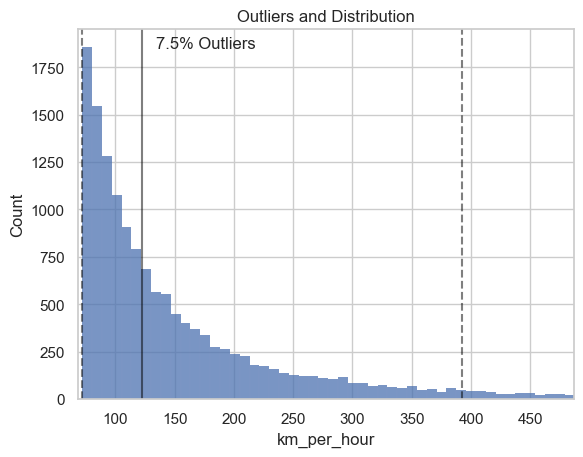

```python
hist_outlier_plot(df["km_per_hour"])
```

This is clearly a problem that would benefit from contacting the data engineering team of Waze if available.

Should we drop, clip, or something else?

#### **`km_per_drive`**

- mean kilometers per drive made in the last month

```python
# Create `km_per_drive` feature
km_per_drive =np.where(df["drives"]!=0,df["driven_km_drives"] / df["drives"],0)
df["km_per_drive"] = km_per_drive
df["km_per_drive"].describe()
```

```
count    14999.000000
mean       232.817946
std        620.622351
min          0.000000
25%         32.424301
50%         72.854343
75%        179.347527
max      15777.426560
Name: km_per_drive, dtype: float64
```

Same issue as above.

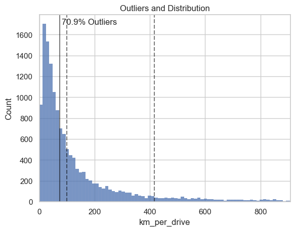

```python
hist_outlier_plot(df["km_per_drive"])
```

#### **`percent_of_sessions_to_favorite`**

- engagement mentric, percentage of total sessions that were used to navigate to users' favorites

```python
# Create `percent_of_sessions_to_favorite` feature
per_to_fav =np.where(df["total_sessions"]!=0,(df["total_navigations_fav1"]+df["total_navigations_fav2"])/df["total_sessions"],0)#.clip(max=1)
df["percent_sessions_to_favorite"] = per_to_fav
df["percent_sessions_to_favorite"].describe()
```

```
count    14999.000000
mean         1.665439
std          8.865666
min          0.000000
25%          0.203471
50%          0.649818
75%          1.638526
max        777.563629
Name: percent_sessions_to_favorite, dtype: float64
```

The 75% percentile having more than 100% is a problem. This is unlikely serve as a valueable feature.

### Summary of FE:

Based on the number of outliers showing up during this process, there may be a big issue with the dataset or a different approach to feature engineering more sensitive to outliers is needed.

# Final Clean

### Drop missing values

```python
# check rows with missing values
missing = df.isna().sum()
for ind,row in missing.items():
    if row >0:
        print(ind,row)
# drop
df.dropna(axis=0,inplace=True)
```

```
label 700
```

### Outliers

It's unclear what to do about outliers considering how many there are in the dataset. If modeling fails, we will revisit out outlier policy.

# Variable encoding

### Dummying feature: Device

```python
# Create new device variable
df["iPhone_user"]=pd.get_dummies(df["device"],drop_first="True",dtype="int64")
```

### Feature selection

```python
# Drop id and engineered columns
df = df.drop(["ID","label","device"],axis=1)
```

### Metric Selection / Class Balance

- Class balance

```python
# Get class balance of 'label' col
df["churned"].value_counts(True)
```

```
churned
0    0.822645
1    0.177355
Name: proportion, dtype: float64
```

Approximately 17.7% of users churned - an unbalanced dataset. Accuracy might not be the best due to imbalance.

If the risks involved in making a false positive prediction are minimal, let use recall score.

# Modeling

## Correlation Check

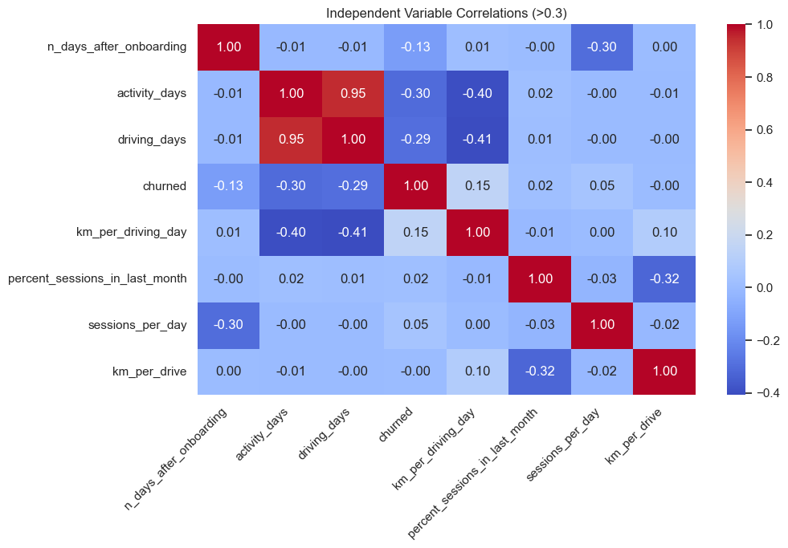

```python
# corr threshold display param
threshold=0.3

df_corr = df.corr()
# remove weak correlations
weak_corr =[]
for col,series in df_corr.items():
    if col == "churned":
        pass
    elif (max(series)<threshold) or (min(series)>-threshold):
        weak_corr.append(col)
# drop weak cols
for i in range(2):
    df_corr.drop(weak_corr,axis=i,inplace=True)
# display
plt.figure(figsize=(10,6))
sns.heatmap(df_corr,annot=True,fmt=".2f",cmap=sns.color_palette("coolwarm",as_cmap="True"))
plt.title(f"Independent Variable Correlations (>{threshold})")
plt.xticks(rotation=45,horizontalalignment="right")
plt.show()
```

### Correlation Matrix Discussion:

There is only one pair of highly correlated variables. If tree-based models weren't employed here, it would be adviseable to remove them.

There are a few features with mostly minor correlation to the outcome `churn`, mostly negative (retention-facing). The outlier-heavy feature `km_per_driving_day` shows a curious correlation toward `churn`.

## Train/Test Split

```python
# set X val
X = df.drop("churned",axis=1)
y= df["churned"]
# train and validate sets
x_train, x_test , y_train, y_test = train_test_split(X,y,train_size=0.7,stratify=y,random_state=42)
# test and validate sets
x_val, x_test , y_val, y_test = train_test_split(x_test,y_test,train_size=0.5,stratify=y_test,random_state=42)
```

Verify number of samples

```python
x_val.shape ,x_test.shape, x_train.shape
```

```
((2145, 18), (2145, 18), (10009, 18))
```

## Init Models

### Init Random forest Model

```python
# 1. Instantiate the random forest classifier

rf_clf = RandomForestClassifier(random_state=42, n_jobs=-1)
# 2. Create a dictionary of hyperparameters to tune

params = {
    "n_estimators": np.arange(50,301,50),
    "max_depth": np.arange(1,19,3),
    "min_samples_split":np.arange(2,11,2),
    "min_samples_leaf":np.arange(1,5,1),
    "max_features":["sqrt","log2",None],
    "bootstrap": [True,False]
}

# 3. Define a dictionary of scoring metrics to capture

scoring = {
    "F1":"f1",
    "Accuracy":"accuracy",
    "Precision":"precision",
    "Recall":"recall",
}
# 4. Instantiate the GridSearchCV object
gs_rf_clf = RandomizedSearchCV(rf_clf,params,cv=10,scoring=scoring,refit="Recall",n_jobs=-1,random_state=42,)
```

### Init Tree Classifier

```python
clf = DecisionTreeClassifier(random_state=42)
param_grid = {
    'max_depth': [2, 3, 4, 5],
    'min_samples_split': [2, 3, 4, 5],
    'min_samples_leaf': [1, 2, 3],
    'max_features': ['sqrt', 'log2', None],
    'criterion': ['gini', 'entropy']
}
gs_clf = RandomizedSearchCV(clf,param_grid, cv=10,scoring=scoring,refit="Recall",n_jobs=-1,random_state=42,)
```

### Init XGBoost

```python
xgb_clf = XGBClassifier(objective="binary:logistic")
param_grid_xgb = {
    'n_estimators': [100, 200, 300],
    'max_depth': [3, 4, 5, 6],
    'learning_rate': [0.01, 0.1, 0.3],
    'subsample': [0.8, 1.0],
    'colsample_bytree': [0.8, 1.0],
    'min_child_weight': [1, 3, 5],
    'gamma': [0, 0.1, 0.2],
    "n_jobs":[-1]
}
gs_xgb = RandomizedSearchCV(xgb_clf,param_grid_xgb, cv=10,scoring=scoring,refit="Recall",n_jobs=-1,random_state=42,)
```

### Training

```python
# set training flag vs loading a model
train = False
model_suite = {"DecisionTreeClassifier":gs_clf,"RandomForestClassifier":gs_rf_clf,"XGBClassifier":gs_xgb}
```

```python
#  train & pickle or load the model
if train:
    for model_name,model in model_suite.items():
        model.fit(x_train,y_train)
        display(model.best_estimator_)
        with open(f"{model_name}.pkl","wb") as file:
            pickle.dump(model,file)
else:
    with open("XGBClassifier.pkl","rb") as file:
        model_suite={"XGBClassifier":pickle.load(file)}
```

```python
for model_name,model in model_suite.items():
    print(model_name)
    cv_results = pd.DataFrame(model.cv_results_)
    display(cv_results[[col for col in cv_results if "mean_test" in col]].sort_values(by="mean_test_Recall",ascending=False).head(3))
```

```
XGBClassifier
```

|  | mean_test_F1 | mean_test_Accuracy | mean_test_Precision | mean_test_Recall |
| --- | --- | --- | --- | --- |
| 2 | 0.272785 | 0.802878 | 0.395134 | 0.209033 |
| 1 | 0.261296 | 0.800481 | 0.382323 | 0.198886 |
| 5 | 0.254782 | 0.806874 | 0.403697 | 0.186495 |

With clipping on percent values, the highest accuracy/recall was 0.795 / 0.196

Without clipping, 0.802 / 0.209

## Model selection

#### **XGBoost**

```python
if train:
    top_model = gs_xgb.best_estimator_
else:
    top_model = model_suite["XGBClassifier"].best_estimator_
```

```python
# Use random forest model to predict on validation data
y_hat = top_model.predict(x_val)
```

Use the `get_test_scores()` function to generate a table of scores from the predictions on the validation data.

```python
def get_test_scores(model_name:str, preds, y_test_data):
    '''
    Generate a table of test scores.

    In:
        model_name (string): Your choice: how the model will be named in the output table
        preds: numpy array of test predictions
        y_test_data: numpy array of y_test data

    Out:
        table: a pandas df of precision, recall, f1, and accuracy scores for your model
    '''
    accuracy = accuracy_score(y_test_data, preds)
    precision = precision_score(y_test_data, preds)
    recall = recall_score(y_test_data, preds)
    f1 = f1_score(y_test_data, preds)

    table = pd.DataFrame({'model': [model_name],
                          'precision': [precision],
                          'recall': [recall],
                          'F1': [f1],
                          'accuracy': [accuracy]
                          })

    return table
```

```python
# Get validation scores to the results table
get_test_scores("XGBoost",y_hat,y_val)
```

|  | model | precision | recall | F1 | accuracy |
| --- | --- | --- | --- | --- | --- |
| 0 | XGBoost | 0.405941 | 0.215223 | 0.281304 | 0.804662 |

**Validation Data Discussion:**

Without clipping 0.804 / 0.215

# Predict on test data

### Confusion matrix

```python
# Generate array of values for confusion matrix
def plot_cm(model,x_test,y_test):
    """
        Generate a confusion matrix for a model.
    """
    y_hat_test = model.predict(x_test)
    cm=confusion_matrix(y_test,y_hat_test,normalize="all")
    sns.heatmap(cm,annot=cm,fmt=".1%",cmap=sns.color_palette("light:b",as_cmap=True),xticklabels=["Actual Retain","Actual Churn"],yticklabels=["Predicted Retain","Predicted Churn"])
    plt.yticks(rotation=0)
    plt.title("Prediction Results:")
    plt.show()
    # Plot confusion matrix
```

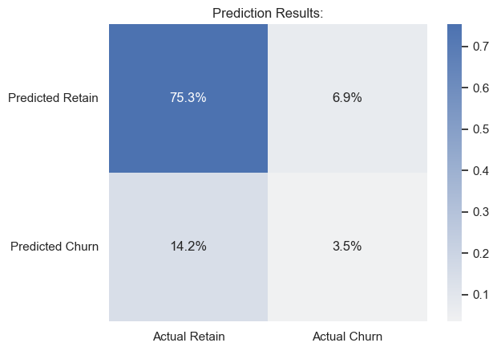

```python
plot_cm(top_model,x_test,y_test)
```

## Feature importance

most important features of final model.

```python
# create Explainer
explainer = shap.TreeExplainer(top_model)
shap_values = explainer.shap_values(x_train,y_train)
```

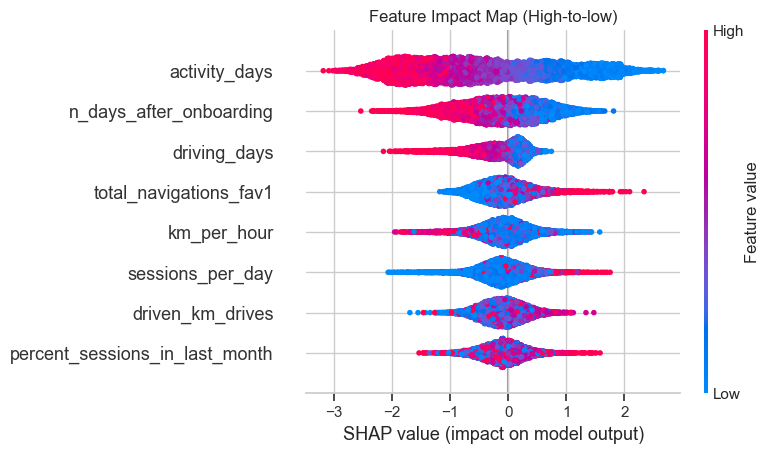

```python
# plot results
plt.title("Feature Impact Map (High-to-low)")
shap.summary_plot(shap_values, x_train, max_display=8)
```

### Explanation

The most impactful values being at the top of the feature impact chart, higher number of days active (and driving days) is a typical indicator of engagement and retention. It is possible that high sessions per day indicates users experiencing technical issues and having to restart frequently as a result. High total navigations to a favorite spot as an indicator of churn makes sense, as users are likely very familiar with their favorite routes and the app adding limited value to well-known routes. Beyond these indicators, the impact is less clear. In addition, most of the engineered features failed to add insight to the model, with some generating extreme outliers.

Any retention strategy should be aimed at users with high sessions per day and frequent navigations to favorite places.

## Optimal decision threshold

The default decision is 0.5.

With imbalanced datasets, this threshold might not be ideal. Lets visualize the trade-off between precision and recall.

```python
def get_clf_threshold(top_model,x_test,y_test,display):
    # Get probability predictions
    y_pred_proba = top_model.predict_proba(x_test)[:, 1]

    # Calculate ROC curve
    fpr, tpr, thresholds = roc_curve(y_test, y_pred_proba)

    # Find threshold that maximizes TPR - FPR
    optimal_idx = np.argmax(tpr - fpr)
    optimal_threshold = thresholds[optimal_idx]

    # Apply optimal threshold
    y_pred_optimal = (y_pred_proba >= optimal_threshold).astype(int)
    if display:
        # visualize ROC Curve
        sns.lineplot(x=fpr,y=tpr)
        sns.lineplot(x=[0,1],y=[0,1],linestyle="--", color="black",alpha=0.6)
        plt.xlabel("False Positive Rate")
        plt.ylabel("True Positive Rate")
        thresh_x = fpr[optimal_idx]
        thresh_y = tpr[optimal_idx]
        # annotate thresh
        plt.scatter(x=thresh_x,y=thresh_y,color="g",edgecolors="black")
        plt.annotate(f"{optimal_threshold:.4f}",(thresh_x+.005,thresh_y-.05))
        sns.despine()
        plt.title("ROC Curve with Threshold for Highest Recall")
        plt.savefig("roc.png", bbox_inches="tight")
        plt.show()
    return y_pred_optimal,optimal_threshold
```

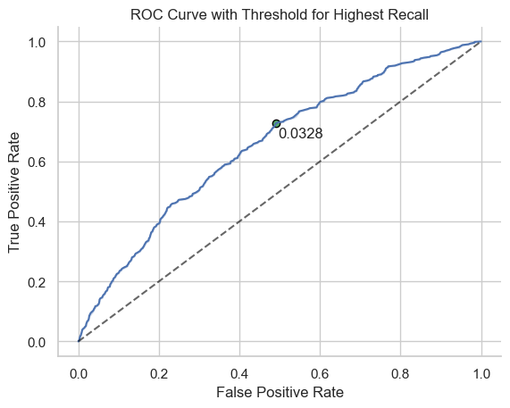

```python
y_pred_optimal,optimal_threshold = get_clf_threshold(top_model,x_test,y_test,display=True)
```

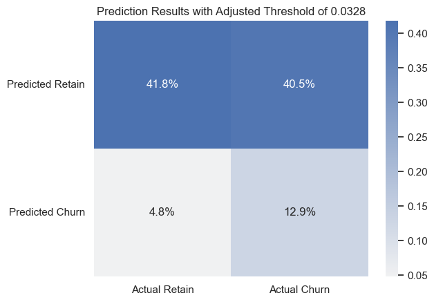

```python
# Generate array of values for confusion matrix

y_hat_test = y_pred_optimal
cm=confusion_matrix(y_test,y_hat_test,normalize="all")
sns.heatmap(cm,annot=cm,fmt=".1%",cmap=sns.color_palette("light:b",as_cmap=True),xticklabels=["Actual Retain","Actual Churn"],yticklabels=["Predicted Retain","Predicted Churn"])
plt.yticks(rotation=0)
plt.title(f"Prediction Results with Adjusted Threshold of {optimal_threshold:.4f}")
plt.savefig("preds_w_adj_thresh.png", bbox_inches="tight")
plt.show()
# Plot confusion matrix
```

```python
get_test_scores(f"XGBoost@{optimal_threshold:.4f}",y_hat_test,y_test)
```

|  | model | precision | recall | F1 | accuracy |
| --- | --- | --- | --- | --- | --- |
| 0 | XGBoost@0.0328 | 0.241921 | 0.728947 | 0.363279 | 0.547319 |

## Post-Test Discussion:

Recall increased significantly at the cost of most other scores. Given the class imbalance of 17.7% and lack of data on the defining features of the app, it's hard to say if much improvement is possible.

There were a large number of anomalous values during feature engineering that can be clipped and/or dropped to try to improve results.

# Second Round Feature Engineering

```python
# make a copy of X
X_1 = df.copy()
X_1.info(False)
```

```
<class 'pandas.core.frame.DataFrame'>
Index: 14299 entries, 0 to 14998
Columns: 19 entries, sessions to iPhone_user
dtypes: float64(9), int64(10)
memory usage: 2.2 MB
```

```python
X_1["churned"].value_counts(True)
```

```
churned
0    0.822645
1    0.177355
Name: proportion, dtype: float64
```

## Clip, Mean-Impute

```python
# clip at 100%
X_1["percent_sessions_in_last_month"] = X_1["percent_sessions_in_last_month"].clip(upper=1)
X_1["percent_sessions_to_favorite"] = X_1["percent_sessions_to_favorite"].clip(upper=1)
```

```python
# mean if outlier
km_col_list = ["km_per_hour","km_per_drive","km_per_driving_day"]
for col,series in X_1[km_col_list].items():
    _,thresh = get_iqr(series)
    X_1[col] = series.where(series >= thresh, series.mean())
```

## Training

```python
# set X val
x1_1 = X_1.drop("churned",axis=1)
y1_1= X_1["churned"]
# train and validate sets
x1_train, x1_test , y1_train, y1_test = train_test_split(x1_1,y1_1,train_size=0.7,stratify=y1_1,random_state=42)
# test and validate sets
x1_val, x1_test , y1_val, y1_test = train_test_split(x1_test,y1_test,train_size=0.5,stratify=y1_test,random_state=42)
```

```python
gs_xgb_1 = RandomizedSearchCV(xgb_clf,param_grid_xgb, cv=10,scoring=scoring,refit="Recall",n_jobs=-1,random_state=42,)
gs_xgb_1.fit(x1_train,y1_train)
with open("gs_xgb_w_clipped_df.pkl","wb") as file:
    pickle.dump(gs_xgb_1,file)
```

## Scoring

```python
y1_hats = gs_xgb_1.best_estimator_.predict(x1_val)
get_test_scores("XBG w Clip",y1_hats,y1_val)
```

|  | model | precision | recall | F1 | accuracy |
| --- | --- | --- | --- | --- | --- |
| 0 | XBG w Clip | 0.346734 | 0.181102 | 0.237931 | 0.793939 |

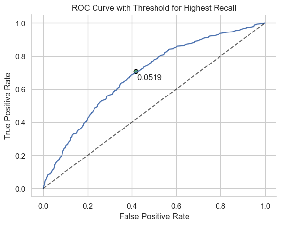

|  | model | precision | recall | F1 | accuracy |
| --- | --- | --- | --- | --- | --- |
| 0 | XBG w Clip Lower Threshold | 0.267928 | 0.706037 | 0.388448 | 0.605128 |

```python
y_pred_optimal,optimal_threshold = get_clf_threshold(gs_xgb_1,x1_val,y1_val,display=True)
get_test_scores("XBG w Clip Lower Threshold",y_pred_optimal,y1_val)
```

## SHAP Values

```python
# create Explainer
new_model = gs_xgb_1.best_estimator_
new_model.__setattr__("base_score",optimal_threshold)
explainer_1 = shap.TreeExplainer(new_model)
shap_values_1 = explainer_1.shap_values(x1_val,y1_val)
```

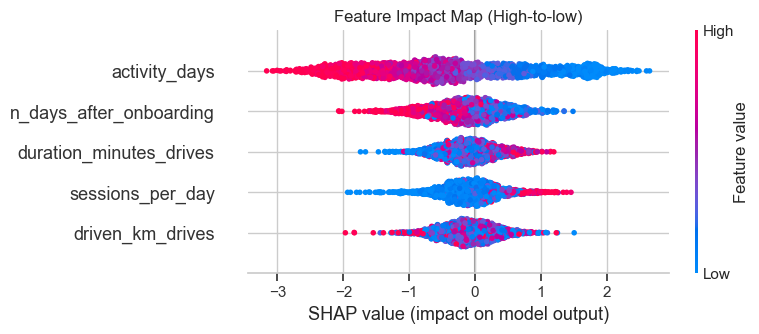

```python
# plot results
plt.title("Feature Impact Map (High-to-low)")
shap.summary_plot(shap_values_1, x1_val, max_display=5, show=False)
plt.savefig("beeswarm_thresh.png", bbox_inches="tight")
plt.show()
```

As a reminder, the original model's features

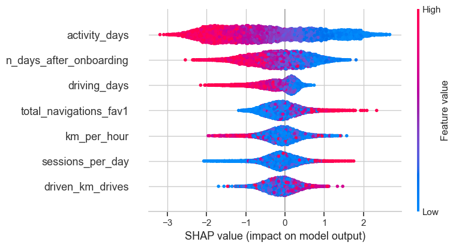

```python
shap.summary_plot(shap_values,x_train,max_display=7, show=False)
plt.savefig("beeswarm_orginial.png", bbox_inches="tight")
plt.show()
```

**A second look at `sessions_per_day`**

```python
print("Number of outliers:",len(X_1[X_1["sessions_per_day"]>X_1["sessions_per_day"].quantile(0.75)]))
X_1["sessions_per_day"].describe()
```

```
Number of outliers: 3575
```

```
count    14299.000000
mean         0.338207
std          1.319814
min          0.000298
25%          0.050818
50%          0.100457
75%          0.215210
max         39.763874
Name: sessions_per_day, dtype: float64
```

There appear to be issues with the session count, as well.

# Outlining Recommendations

```python
top_feat = X[["activity_days","n_days_after_onboarding","sessions_per_day"]]
df_churned =df[df["churned"]==1]
df_stay =df[df["churned"]==0]
```

```python
def pop_within_param(indicator,lower_thres,upper_thres,verbose=False,inside=True) -> float:
    """
    Returns a percent based on a column and its upper and lower limits.
    """
    total_pop = 0
    for df in [df_stay,df_churned]:
        if inside == True:
            ppop = df[(df[indicator] <= upper_thres) & (df[indicator] >= lower_thres)]["churned"].count()
        else:
            ppop = df[(df[indicator] >= upper_thres) | (df[indicator] <= lower_thres)]["churned"].count()
        #per_pop = ppop/df.shape[0]
        #print(per_pop,",", ppop,"of",df.shape[0])
        total_pop += ppop
        total_sample = ppop
    if total_sample:
        tpop = total_sample/df_churned.shape[0]
    else:
        tpop = 0
    if verbose:
        print(f"based on {indicator}({lower_thres}-{upper_thres}):{tpop:.2%} of all churn ({total_sample} / {total_pop} {total_sample/total_pop:.2%})")
    return tpop,total_pop
```

```python
def get_churn_range(col_name,max_window_size=10,pop_priority=True):
    top_val = 0
    top_pop = 0
    top_range=[]
    coeff = 0
    for j in range(1,max_window_size):
        width = j
        for i in np.arange(width,df[col_name].max(),width):
            result, sample_pop = pop_within_param(col_name,i-width,i+width)
            sample_coeff = result * sample_pop / df.shape[0]
            if pop_priority:
                if sample_coeff > coeff:
                    coeff = sample_coeff
                    top_val = result
                    top_range = [i-width,i+width]
                    top_pop = sample_pop / df.shape[0]
            else:
                if (result > top_val) & (sample_pop > top_pop):
                    top_val = result
                    top_range = [i-width,i+width]
                    top_pop = sample_pop / df.shape[0]
    print(f"Contains {top_val:.2%} all churn, within {top_range},{top_pop:.2%} of population")
```

## Activity Day Ranges

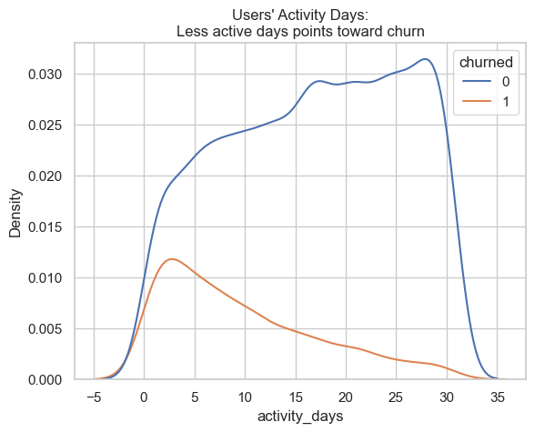

```python
sns.kdeplot(df,x="activity_days",hue="churned")
plt.title("Users' Activity Days:\nLess active days points toward churn")
plt.savefig("activity_days.png", bbox_inches="tight")
plt.show()
```

```python
get_churn_range("activity_days",5, False)
```

```
Contains 54.22% all churn, within [np.int64(0), np.int64(8)],27.69% of population
```

```python
get_churn_range("activity_days",10, True)
```

```
Contains 84.70% all churn, within [np.int64(0), np.int64(18)],59.47% of population
```

```python
pop_within_param("activity_days",1,18,True)
```

```
based on activity_days(1-18):80.76% of all churn (2048 / 8270 24.76%)
```

```
(np.float64(0.807570977917981), np.int64(8270))
```

```python
df[(df["activity_days"]>0) & (df["activity_days"]<4)]["churned"].value_counts()
```

```
churned
0    843
1    570
Name: count, dtype: int64
```

## N_days Ranges

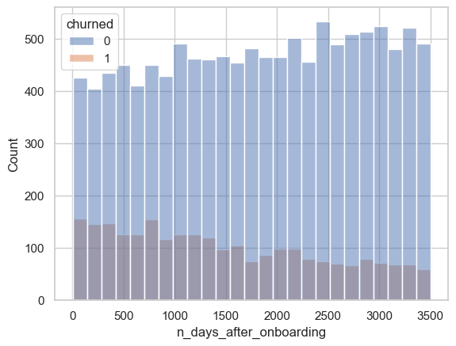

```python
sns.histplot(df,x="n_days_after_onboarding",hue="churned")
plt.show()
```

```python
get_churn_range("n_days_after_onboarding",30, False)
```

```
Contains 2.96% all churn, within [np.int64(754), np.int64(812)],1.84% of population
```

## Sessions per day Ranges

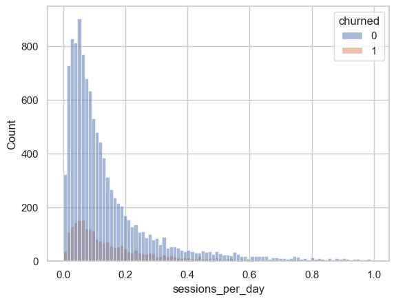

```python
sns.histplot(df[df["sessions_per_day"]<=1], x="sessions_per_day",hue="churned")
plt.show()
```

```python
import scipy.stats as stats
stats.ttest_ind(df_churned["sessions_per_day"],df_stay["sessions_per_day"], equal_var=False)
```

```
TtestResult(statistic=np.float64(4.582852172347418), pvalue=np.float64(4.7696058977730875e-06), df=np.float64(3071.4960885606265))
```

```python
df_churned["sessions_per_day"].describe()
```

```
count    2536.000000
mean        0.475864
std         1.751613
min         0.001213
25%         0.061912
50%         0.130587
75%         0.300388
max        34.384712
Name: sessions_per_day, dtype: float64
```

```python
df_stay["sessions_per_day"].describe()
```

```
count    11763.000000
mean         0.308530
std          1.204680
min          0.000298
25%          0.048858
50%          0.095494
75%          0.198782
max         39.763874
Name: sessions_per_day, dtype: float64
```

```python
get_churn_range("sessions_per_day",10)
```

```
Contains 99.68% all churn, within [np.float64(0.0), np.float64(18.0)],99.86% of population
```

```python
get_churn_range("sessions_per_day",2, False)
```

```
Contains 96.10% all churn, within [np.float64(0.0), np.float64(2.0)],97.34% of population
```

## total Navs to Fav1

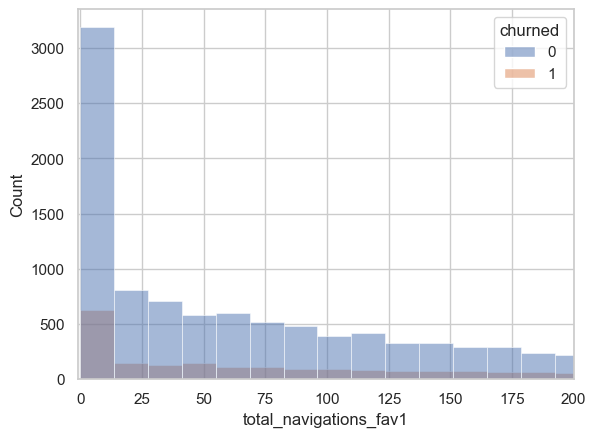

```python
sns.histplot(df,x="total_navigations_fav1",hue="churned")
plt.xlim(-1,200)
plt.savefig("total_nav_fav.png", bbox_inches="tight")
plt.show()
```

```python
get_churn_range("total_navigations_fav1",15, False)
```

```
Contains 30.76% all churn, within [np.int64(0), np.int64(28)],33.79% of population
```

```python
pop_within_param("total_navigations_fav1",0,28)
```

```
(np.float64(0.30757097791798105), np.int64(4832))
```

# Conclusion

Recall of 0.706 and accuracy of 0.605 are below industry standards, even after applying mean-imputation, but the recall score could be high enough to use if the retention strategy is a low cost one, such as sending reminders via notifications.

This model can only recommended under low-risk, low-cost circumstances.

```python
df[(df["activity_days"]<=18) | (df["total_navigations_fav1"]<=28)]["churned"].value_counts(normalize=True)
```

```
churned
0    0.783338
1    0.216662
Name: proportion, dtype: float64
```

```python
df[(df["activity_days"]<=18)]["churned"].value_counts(True)
```

```
churned
0    0.747383
1    0.252617
Name: proportion, dtype: float64
```

```python
df[(df["total_navigations_fav1"]<=28)]["churned"].value_counts(True)
```

```
churned
0    0.838576
1    0.161424
Name: proportion, dtype: float64
```